# Slay Slay Fashion Slurp

Jackson, Abby, Karen, Kai

2024-11-21

## Justification

**Introduction**: Dragons have mucus that allows them to produce flames – this material is flammable but has low ignition potential so this is safe to collect. Dragon mucus is societally important as it is a green fuel allowing for transition away from fossil fuels. Location: Tolkien post industrial revolution dragon village

**Methods**: Over a period of several months, we asked 5-10 dragons a day in the village to collect all their oral/nasal mucus secretions for a 24 hour period. We also asked the dragons to weigh themselves once in the middle of the collection period.

**Variables**:

- Pounds of mucus secreted a day
  - We compensated the dragons for their mucus at the market rate
- Dragon size
  - We predict this is correlated with age as dragons turn into rocks as they age & get bigger (and rocks don’t secrete mucus)
  - Potential for future study, but concerned with potential ageism ramifications for elder dragons who become less societally important, hence why it is not included in this study

## Data

```r
library(bbmle)
```

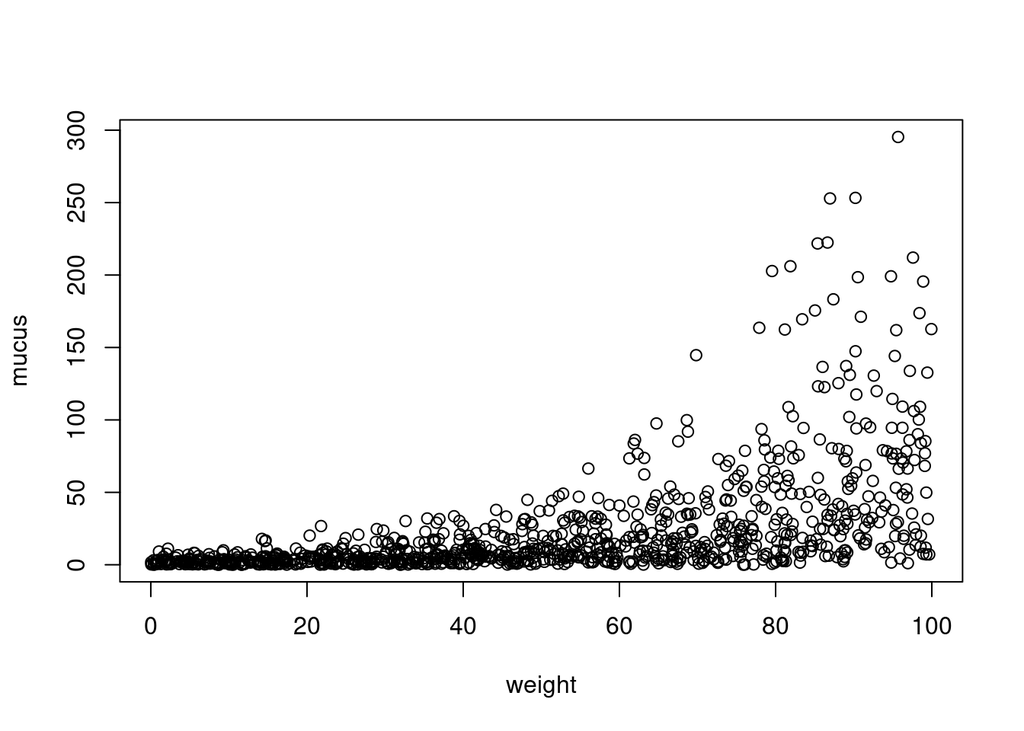

```r
set.seed(123)

# Simulate data (exponential distribution)
first <- 1.74
second <- 0.04

inv_link_function <- function(z) {return( 1/z)}

myExpSim <- function(i){
  Myrate = first * exp(second*i)

  responseI = rexp(n=length(i), rate = inv_link_function(Myrate) ) # generate 1000 response values
  return(responseI)
}

weight <- runif(1000, min=0, max=100) # predictor
mucus <- myExpSim(weight) # response


# Visualize
plot(weight,mucus)
```

## Inference

```r
dragon_data <- data.frame(weight=weight,mucus=mucus)

# Deterministic function - exponential decay
det_funct <- function(data, a, r){ return (a * exp(r*data)) }

# Inverse link function (canonical - negative inverse)
 inv_link_function <- function(z) {return( 1/z)}

mod <- mle2(mucus ~ dexp(rate=inv_link_function(det_funct(weight,a,r))),
            data=dragon_data,
            start=list("a"=1,"r"=0))
mod
```

```
##
## Call:
## mle2(minuslogl = mucus ~ dexp(rate = inv_link_function(det_funct(weight,
##     a, r))), start = list(a = 1, r = 0), data = dragon_data)
##
## Coefficients:
##          a          r
## 2.02088035 0.03759146
##
## Log-likelihood: -3573.01
```

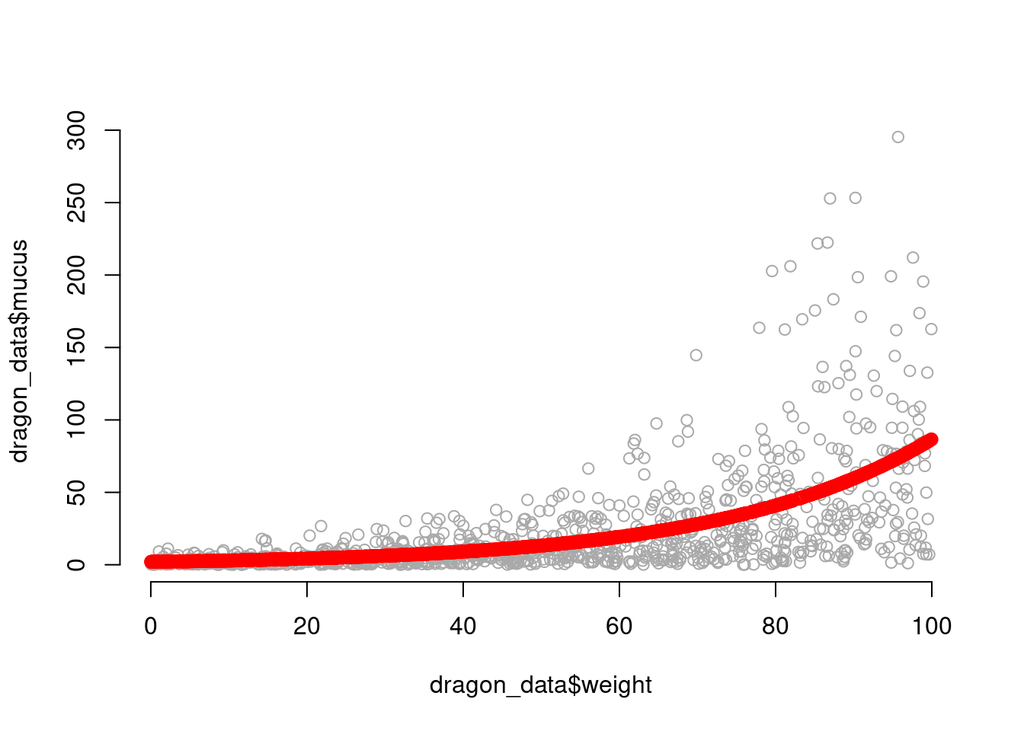

```r
modData = det_funct(dragon_data$weight,mod@coef["a"], mod@coef["r"])

## look at the model-predicted data curve on top of the actual data

plot(dragon_data$weight, dragon_data$mucus, bty="n", col="darkgray")
points(dragon_data$weight, modData,col="red",lwd=2)
```

```r
write.csv(dragon_data, file="dragon_data2.csv")
```